# BIOS 6624: Project 2

Ryan Summers

2026-03-13

## Load Data

```r
prelim_df <- read_csv("/Users/ryan_summers/GitHub/BIOS6624-Class/Project2/DataRaw/PrelimData.csv")
```

## Exploratory Data Analysis (EDA)

Calculate correlations between predictors and outcomes

```r
cat(
"Pearson correlation between predictor inflammatory marker IL-6 and outcome
  cognitive measure CVLT is", round(cor(prelim_df$IL_6, prelim_df$CVLT_CNG3),3),
  "in the 95% confidence range of",
  round(cor.test(prelim_df$IL_6,prelim_df$CVLT_CNG3)$conf.int[1],3), "to",
  round(cor.test(prelim_df$IL_6, prelim_df$CVLT_CNG3)$conf.int[2],3),
  "\n\n")
```

```
## Pearson correlation between predictor inflammatory marker IL-6 and outcome
##   cognitive measure CVLT is -0.259 in the 95% confidence range of -0.566 to 0.112
```

```r
cat(
"Pearson correlation between predictor inflammatory marker IL-6 and outcome
  cortical thickness is", round(cor(prelim_df$IL_6, prelim_df$CORT_CNG3),3)
  ,"in the 95% confidence range of",
  round(cor.test(prelim_df$IL_6, prelim_df$CORT_CNG3)$conf.int[1],3), "to",
  round(cor.test(prelim_df$IL_6, prelim_df$CORT_CNG3)$conf.int[2],3),
  "\n\n")
```

```
## Pearson correlation between predictor inflammatory marker IL-6 and outcome
##   cortical thickness is -0.599 in the 95% confidence range of -0.789 to -0.305
```

```r
cat(
  "Pearson correlation between predictor inflammatory marker MCP-1 and outcome
  cognitive measure CVLT is", round(cor(prelim_df$MCP_1, prelim_df$CVLT_CNG3),3),
  "in the 95% confidence range of",
  round(cor.test(prelim_df$MCP_1, prelim_df$CVLT_CNG3)$conf.int[1],3), "to",
  round(cor.test(prelim_df$MCP_1, prelim_df$CVLT_CNG3)$conf.int[2],3),
  "\n\n")
```

```
## Pearson correlation between predictor inflammatory marker MCP-1 and outcome
##   cognitive measure CVLT is -0.318 in the 95% confidence range of -0.609 to 0.047
```

```r
cat(
  "Pearson correlation between predictor inflammatory marker MCP-1 and outcome
  cortical thickness is", round(cor(prelim_df$MCP_1, prelim_df$CORT_CNG3),3),
  "in the 95% confidence range of",
  round(cor.test(prelim_df$MCP_1, prelim_df$CORT_CNG3)$conf.int[1],3), "to",
  round(cor.test(prelim_df$MCP_1, prelim_df$CORT_CNG3)$conf.int[2],3),
  "\n\n")
```

```
## Pearson correlation between predictor inflammatory marker MCP-1 and outcome
##   cortical thickness is -0.685 in the 95% confidence range of -0.839 to -0.432
```

```r
cat(
  "Pearson correlation between predictor inflammatory marker MCP-1 and predictor
  IL-6 is", round(cor(prelim_df$MCP_1, prelim_df$IL_6),3),
  "in the 95% confidence range of",
  round(cor.test(prelim_df$MCP_1, prelim_df$IL_6)$conf.int[1],3), "to",
  round(cor.test(prelim_df$MCP_1, prelim_df$IL_6)$conf.int[2],3),
  "\n\n")
```

```
## Pearson correlation between predictor inflammatory marker MCP-1 and predictor
##   IL-6 is 0.934 in the 95% confidence range of 0.864 to 0.968
```

```r
cat(
  "Pearson correlation between outcome cognitive and cortical measures is",
  round(cor(prelim_df$CVLT_CNG3, prelim_df$CORT_CNG3),3),
  "in the 95% confidence range of",
  round(cor.test(prelim_df$CVLT_CNG3, prelim_df$CORT_CNG3)$conf.int[1],3), "to",
  round(cor.test(prelim_df$CVLT_CNG3, prelim_df$CORT_CNG3)$conf.int[2],3),
  "\n\n")
```

```
## Pearson correlation between outcome cognitive and cortical measures is 0.156 in the 95% confidence range of -0.217 to 0.489
```

```r
cor.test(prelim_df$IL_6, prelim_df$CVLT_CNG3)$conf.int[1]
```

```
## [1] -0.5660978
```

```r
test <- cor.test(prelim_df$IL_6, prelim_df$CVLT_CNG3)
test$conf.int
```

```
## [1] -0.5660978  0.1121550
## attr(,"conf.level")
## [1] 0.95
```

Sample interpretation: Preliminary data suggest correlations between inflammatory marker IL-6 and outcome changes from baseline to year-1 in CVLT are in the 95% confidence range of -0.566 to 0.112 with a point estimate of -0.259, which informed the range of correlations evaluated in the power analysis.

```r
# sample models
il6.cvlt.model <- lm(CVLT_CNG3~IL_6, data=prelim_df)
tidy(il6.cvlt.model)
```

```
## # A tibble: 2 × 5
##   term        estimate std.error statistic p.value
##   <chr>          <dbl>     <dbl>     <dbl>   <dbl>
## 1 (Intercept)  -0.750     0.498      -1.51   0.143
## 2 IL_6         -0.0999    0.0705     -1.42   0.168
```

```r
il6.cort.model <- lm(CORT_CNG3~IL_6, data=prelim_df)
tidy(il6.cort.model)
```

```
## # A tibble: 2 × 5
##   term        estimate std.error statistic    p.value
##   <chr>          <dbl>     <dbl>     <dbl>      <dbl>
## 1 (Intercept)   -2.98     0.542      -5.50 0.00000702
## 2 IL_6          -0.304    0.0768     -3.96 0.000466
```

```r
mcp.cvlt.model <- lm(CVLT_CNG3~MCP_1, data=prelim_df)
tidy(mcp.cvlt.model)
```

```
## # A tibble: 2 × 5
##   term        estimate std.error statistic p.value
##   <chr>          <dbl>     <dbl>     <dbl>   <dbl>
## 1 (Intercept)  -0.0714    0.771    -0.0925  0.927
## 2 MCP_1        -0.122     0.0687   -1.78    0.0864
```

```r
mcp.cort.model <- lm(CORT_CNG3~MCP_1, data=prelim_df)
tidy(mcp.cort.model)
```

```
## # A tibble: 2 × 5
##   term        estimate std.error statistic   p.value
##   <chr>          <dbl>     <dbl>     <dbl>     <dbl>
## 1 (Intercept)   -1.20     0.778      -1.55 0.133
## 2 MCP_1         -0.345    0.0693     -4.98 0.0000294
```

```r
# both predictors in model
cvlt.model <- lm(CVLT_CNG3~MCP_1+IL_6, data=prelim_df)
tidy(cvlt.model)
```

```
## # A tibble: 3 × 5
##   term        estimate std.error statistic p.value
##   <chr>          <dbl>     <dbl>     <dbl>   <dbl>
## 1 (Intercept)    0.345     1.05      0.329   0.745
## 2 MCP_1         -0.230     0.194    -1.18    0.246
## 3 IL_6           0.116     0.195     0.595   0.557
```

```r
cort..model <- lm(CORT_CNG3~MCP_1+IL_6, data=prelim_df)
tidy(cort..model)
```

```
## # A tibble: 3 × 5
##   term        estimate std.error statistic p.value
##   <chr>          <dbl>     <dbl>     <dbl>   <dbl>
## 1 (Intercept)   -0.633     1.05     -0.602  0.552
## 2 MCP_1         -0.493     0.195    -2.53   0.0174
## 3 IL_6           0.160     0.196     0.814  0.423
```

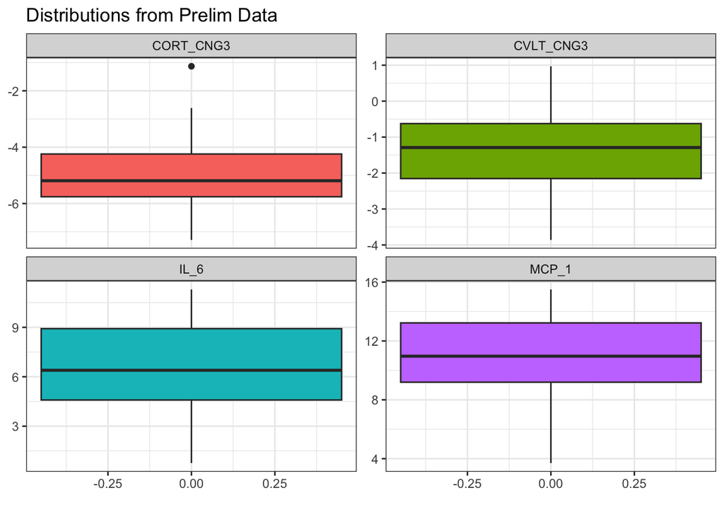

```r
# convert df to long
prelim_long <- prelim_df %>%
  pivot_longer(
    cols = c(CVLT_CNG3, CORT_CNG3, IL_6, MCP_1),
    names_to = "variable", values_to = "value")

ggplot(prelim_long, aes(y = value, fill = variable)) +
  geom_boxplot(width = 0.9) +
  facet_wrap(~ variable, scales = "free_y") +
  labs(
    title = "Distributions from Prelim Data",
    x = "",
    y = NULL) +
  theme_bw() +
  theme(legend.position = "none")
```

## Aim 1 Power Analysis

```r
# function get corr estimate and 95% CI
cor_ci <- function(data, x, y) {
  ct <- cor.test(data[[x]], data[[y]])
  tibble(
    predictor = x,
    outcome   = y,
    r         = unname(ct$estimate),
    ci_low    = ct$conf.int[1],
    ci_high   = ct$conf.int[2],
    p_value   = ct$p.value,
    n         = sum(complete.cases(data[[x]], data[[y]])))
  }

# correlations for pilot effect-size range
cor_results <- bind_rows(
  cor_ci(prelim_df, "IL_6", "CVLT_CNG3"),
  cor_ci(prelim_df, "IL_6", "CORT_CNG3"),
  cor_ci(prelim_df, "MCP_1", "CVLT_CNG3"),
  cor_ci(prelim_df, "MCP_1", "CORT_CNG3"),
  cor_ci(prelim_df, "IL_6", "MCP_1"),  # predictor-predictor
  cor_ci(prelim_df, "CVLT_CNG3", "CORT_CNG3"))       # outcome-outcome
```

How large the correlation between an inflammatory marker and outcome decline must be to achieve 80% power under different significance thresholds (α) for sample size 175. Power decreases toward zero because weaker associations are harder to detect.

```r
pred_vars <- c("IL_6", "MCP_1")
out_vars  <- c("CVLT_CNG3", "CORT_CNG3")

# filter to only predictor and outcome correlation calculations
aim1_pairs <- cor_results %>%
  dplyr::filter(
    predictor %in% pred_vars,
    outcome %in% out_vars)

# primary and conservative alpha
alpha_grid <- c(0.01, 0.005, 0.0025)

# initialize results object
aim1_pwr_results <- data.frame()

# loop over each pilot predictor-outcome pair
for (i in seq_len(nrow(aim1_pairs))) {

  pred_i <- aim1_pairs$predictor[i]
  out_i  <- aim1_pairs$outcome[i]
  r_hat  <- aim1_pairs$r[i]

  # define correlation range based on pilot data
  r_low  <- max(r_hat - 0.30, -0.99)
  r_high <- min(r_hat + 0.30,  0.99)
  r_grid <- seq(r_low, r_high, by = 0.01)

  for (a in alpha_grid) {
    for (r in r_grid) {
      # power function
      pwr <- powertools::corr.1samp(
        N = 175, # target sample size
        rho0 = 0,
        rhoA = r,
        alpha = a,
        sides = 2)
      # converts to long format
      aim1_pwr_results <- rbind(
        aim1_pwr_results,
        data.frame(
          predictor = pred_i,
          outcome   = out_i,
          pilot_r   = r_hat,
          r         = r,
          alpha     = a,
          power     = pwr))
    }
  }
  }
```

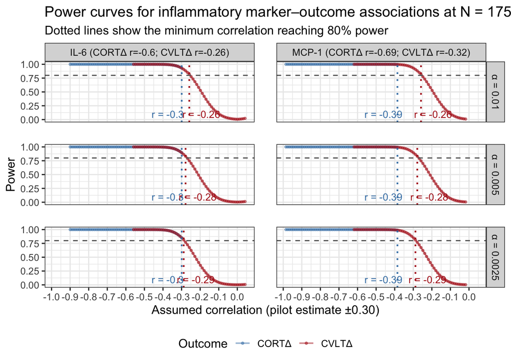

```r
# plotting dataset
aim1_plot_dat <- aim1_pwr_results %>%
  mutate(
    alpha = factor(
      alpha,
      levels = c(0.01, 0.005, 0.0025),
      labels = c("α = 0.01",
        "α = 0.005", "α = 0.0025"))) %>%
  arrange(alpha, predictor, outcome, r)

# min detectable correlation for 80% power
aim1_min_r_80 <- aim1_plot_dat %>%
  dplyr::filter(power >= 0.80) %>%
  group_by(predictor, outcome, alpha) %>%
  slice_min(order_by = abs(r), n = 1, with_ties = FALSE) %>%
  ungroup() %>%
  mutate(r_label = paste0("r = ", round(r, 2)))

# label positions
aim1_min_r_80_labels <- aim1_min_r_80 %>%
  dplyr::mutate(
    label_x = dplyr::case_when(
      outcome == "CORT_CNG3" ~ r - 0.075,
      outcome == "CVLT_CNG3" ~ r + 0.065),
    label_y = 0.10)

# plot
ggplot(aim1_plot_dat, aes(x = r, y = power, color = outcome)) +
  geom_line(linewidth = 0.7, alpha = 0.5) +
  geom_point(size = 0.8, alpha = 0.5) +
  geom_hline(yintercept = 0.80, linetype = "dashed", color = "grey40") +
  geom_vline(
    data = aim1_min_r_80,
    aes(xintercept = r, color = outcome),
    linetype = "dotted",
    linewidth = 0.8,
    show.legend = F) +
  geom_text(
    data = aim1_min_r_80_labels,
    aes(x = label_x, y = label_y, label = r_label, color = outcome),
    size = 3.5,
    show.legend = F) +
  facet_grid(
    alpha ~ predictor,
    labeller = labeller(
      predictor = c(IL_6 = "IL-6 (CORTΔ r=-0.6; CVLTΔ r=-0.26)",
                    MCP_1 = "MCP-1 (CORTΔ r=-0.69; CVLTΔ r=-0.32)"))) +
  scale_color_manual(
    values = c("CORT_CNG3" = "steelblue", "CVLT_CNG3" = "firebrick"),
    labels = c("CORT_CNG3" = "CORTΔ", "CVLT_CNG3" = "CVLTΔ")) +
  scale_x_continuous(breaks = seq(-1, 1, by = 0.1)) +
  labs(
    x = "Assumed correlation (pilot estimate ±0.30)",
    y = "Power",
    color = "Outcome",
    title = "Power curves for inflammatory marker–outcome associations at N = 175",
    subtitle = "Dotted lines show the minimum correlation reaching 80% power") +
  coord_cartesian(ylim = c(0, 1)) +
  theme_bw(base_size = 12) +
  theme(
    panel.spacing = unit(1.5, "lines"),
    legend.position = "bottom")
```

```r
r_grid <- seq(-0.5, -0.2, by = 0.01)
alpha_grid <- c(0.05/4, 0.05/10, 0.05/20)

aim1_power_full <- data.frame()

for (a in alpha_grid) {
  for (r in r_grid) {

    pwr <- corr.1samp(
      N = 175,
      rho0 = 0,
      rhoA = r,
      alpha = a,
      sides = 2)

    aim1_power_full <- rbind(
      aim1_power_full,
      data.frame(r = r, alpha = a, power = pwr))
  }
  }
```

```r
min_r_80 <- aim1_power_full %>%
  dplyr::filter(power >= 0.80) %>%
  group_by(alpha) %>%
  slice_min(order_by = abs(r), n = 1, with_ties = FALSE) %>%
  ungroup()
```

```r
r_vals <- c(-0.20, -0.25, -0.30, -0.35, -0.40, -0.45, -0.50)

aim1_power_table <- aim1_power_full %>%
  dplyr::filter(round(r, 2) %in% r_vals)

min_r_80_row <- min_r_80 %>%
  dplyr::mutate(
    alpha = dplyr::case_when(
      alpha == 0.0125 ~ "α = 0.05/4",
      alpha == 0.005 ~ "α = 0.05/10",
      alpha == 0.0025 ~ "α = 0.05/20"),
    value = round(abs(r)*100, 1)) %>%
  dplyr::select(alpha, value) %>%
  pivot_wider(
    names_from = alpha,
    values_from = value) %>%
  mutate(correlation = "Min |r| for 80% power") %>%
  dplyr::select(correlation, `α = 0.05/4`, `α = 0.05/10`, `α = 0.05/20`)

aim1_power_table_wide <- aim1_power_table %>%
  mutate(
    correlation = sprintf("%.2f", abs(r)),
    alpha = case_when(
      alpha == 0.0125 ~ "α = 0.05/4",
      alpha == 0.005  ~ "α = 0.05/10",
      alpha == 0.0025 ~ "α = 0.05/20"),
    power = round(power * 100, 1)) %>%
  dplyr::select(correlation, alpha, power) %>%
  pivot_wider(
    names_from = alpha,
    values_from = power)

final_table <- dplyr::bind_rows(
  aim1_power_table_wide,
  min_r_80_row)

final_table
```

```
## # A tibble: 8 × 4
##   correlation           `α = 0.05/4` `α = 0.05/10` `α = 0.05/20`
##   <chr>                        <dbl>         <dbl>         <dbl>
## 1 0.50                         100           100           100
## 2 0.45                         100           100           100
## 3 0.40                          99.9          99.7          99.5
## 4 0.35                          99            97.7          96.3
## 5 0.30                          94.2          89.7          85.3
## 6 0.25                          80.6          71            63.2
## 7 0.20                          56.7          44.4          36.1
## 8 Min |r| for 80% power         25            28            29
```

```r
gt_power_table <- final_table %>%
  gt(rowname_col = "correlation") %>%
  tab_header(
    title = md("**Aim 1 Power at N = 175**"),
    subtitle = md("Power (%) across assumed correlations and
                  significance thresholds")) %>%
  tab_stubhead(label = md("**Assumed |r|**")) %>%  # Add this line
  cols_label(
    correlation = "Assumed |r|",
    `α = 0.05/4`   = md("**α = 0.05/4**"),
    `α = 0.05/10`  = md("**α = 0.05/10**"),
    `α = 0.05/20` = md("**α = 0.05/20**")) %>%

   cols_width(
    stub() ~ px(150),  # This controls the stub column width
    everything() ~ px(87)  # Optional: control other column widths
  ) %>%

  fmt_missing(
    columns = everything(),
    missing_text = "") %>%
  tab_style(
    style = list(cell_text(weight = "bold")),
    locations = cells_stub(rows = correlation == "Min |r| for 80% power")) %>%
  tab_style(
    style = list(cell_text(weight = "bold")),
    locations = cells_body(
      rows = correlation == "Min |r| for 80% power",
      columns = c(`α = 0.05/4`, `α = 0.05/10`, `α = 0.05/20`))) %>%

  # Add these tab_style calls for background highlighting
  tab_style(
    style = list(
      cell_borders(
        sides = c("top", "bottom"),
        color = "gray60",
        weight = px(1),
        style = "solid"),
      cell_fill(color = "lightgreen")),
    locations = cells_body(
      rows = correlation == "Min |r| for 80% power",
      columns = everything())) %>%
  tab_style(
    style = list(
      cell_borders(
        sides = c("top", "bottom"),
        color = "gray60",
        weight = px(1),
        style = "solid"),
      cell_fill(color = "lightgreen")),
    locations = cells_stub(
      rows = correlation == "Min |r| for 80% power")) %>%

  tab_spanner(label = md("**Power (%)**"),
              columns = c(`α = 0.05/4`, `α = 0.05/10`, `α = 0.05/20`)) %>%
  tab_source_note(
    source_note = md(
      "Minimum detectable correlation corresponds to the smallest absolute
      correlation achieving at least 80% power.")) %>%
  tab_options(
    table.width = pct(65),
    table.border.left.style = "none",
    table.border.right.style = "none",
    stub.border.style = "none",
    table.font.size = px(12),
    heading.title.font.size = px(14),
    heading.subtitle.font.size = px(11),
    data_row.padding = px(4),
    source_notes.font.size = px(10))
gt_power_table
```

**Aim 1 Power at N = 175**

Power (%) across assumed correlations and significance thresholds

| **Assumed \|r\|** | **Power (%)** **α = 0.05/4** | **Power (%)** **α = 0.05/10** | **Power (%)** **α = 0.05/20** |
| --- | --- | --- | --- |
| 0.50 | 100.0 | 100.0 | 100.0 |
| 0.45 | 100.0 | 100.0 | 100.0 |
| 0.40 | 99.9 | 99.7 | 99.5 |
| 0.35 | 99.0 | 97.7 | 96.3 |
| 0.30 | 94.2 | 89.7 | 85.3 |
| 0.25 | 80.6 | 71.0 | 63.2 |
| 0.20 | 56.7 | 44.4 | 36.1 |
| Min \|r\| for 80% power | 25.0 | 28.0 | 29.0 |

Minimum detectable correlation corresponds to the smallest absolute correlation achieving at least 80% power.

Example interpretation: Preliminary data were used to estimate correlations between inflammatory markers and outcome change scores. Because outcomes were defined as baseline minus year-1 values, greater inflammation is expected to be associated with greater decline, corresponding to negative correlations. Power analyses therefore evaluated a range of plausible negative correlations informed by the preliminary estimates.

## Aim 2 Power Analysis

Does AD deposition modify the association between inflammation and 1-year change? * Specifically, patients with greater amyloid accumulation and elevated inflammation will show the greatest decline in memory and AD-signature cortical thickness.

For Aim 2, amyloid deposition will be operationalized as amyloid positive versus amyloid negative based on established Florbetapir PET cutoffs (global SUVR threshold 1.10). This approach is consistent with the grant’s stated alternative analytic strategy and provides a more feasible and interpretable framework for power analysis than modeling an interaction between two continuous variables. We will test whether the association between inflammation and 1-year change in outcomes differs by amyloid status by fitting change-score regression models including inflammation, amyloid group, and their interaction term.

For Aim 2, power calculations will evaluate the incremental effect of the inflammation x amyloid-status interaction in linear regression models for 1-year change outcomes. Because amyloid will be treated as a dichotomous PET-based variable, this provides a more feasible approximation of the proposed moderation hypothesis than a continuous-by-continuous interaction.

For Aim 2, power will be evaluated for the added inflammation × amyloid-status interaction term using mlrF.partial, with the reduced model including inflammation, amyloid group, age, sex, CDR, and APOE genotype, and the full model additionally including the interaction term.

```r
## number of predictors in full model:
## inflammation + factor(amyloid) + interaction + covariates
## covariates: age, sex, CDR, APOE = 4
## total full-model predictors = 1 + 1 + 1 + 4 = 7
p <- 6   # covariates (4) + inflammation(1) + amyloid (1) - per model
q <- 1   # amyloid*inflammation - one interaction term - per model


## plausible interaction partial correlations
## literature states that interactions are typically much smaller than main effects
  ## 1/3 of main effects in some studies
pc_grid <- seq(0.03, 0.4, by = 0.01)

# initialize aim 2 results object
aim2_pwr_results <- data.frame()

for (a in alpha_grid) {
  for (pc in pc_grid) {

    pwr <- powertools::mlrF.partial(
      N = 175,
      p = p,
      q = q,
      pc = pc, # pc only accepts positive correlations
      alpha = a)

    aim2_pwr_results <- rbind(
      aim2_pwr_results,
      data.frame(
        pc = pc,
        alpha = a,
        power = pwr))
  }
  }
```

```r
# plotting data
aim2_plot_dat <- aim2_pwr_results %>%
  mutate(
    alpha = factor(
      alpha,
      levels = c(0.05, 0.01, 0.005, 0.0025),
      labels = c("α = 0.05", "α = 0.01",
        "α = 0.005", "α = 0.0025"))) %>%
  arrange(alpha, pc)

# minimum detectable interaction for 80% power
aim2_min_pc_80 <- aim2_plot_dat %>%
  filter(power >= 0.80) %>%
  group_by(alpha) %>%
  slice_min(order_by = pc, n = 1, with_ties = FALSE) %>%
  ungroup() %>%
  mutate(
    pc_label = paste0("r = ", round(pc, 2)),
    label_x = pc + 0.01,
    label_y = 0.08)

# label positions
aim2_min_pc_80_labels <- aim2_min_pc_80 %>%
  mutate(
    pc_label = paste0("r = ", round(pc, 2)),
    label_x = case_when(
      alpha == "α = 0.05"  ~ pc - 0.015,
      alpha == "α = 0.01"  ~ pc - 0.015,
      alpha == "α = 0.005"  ~ pc + 0.005,
      alpha == "α = 0.0025" ~ pc + 0.015),
    label_y = case_when(
      alpha == "α = 0.05"  ~ 0.08,
      alpha == "α = 0.01"  ~ 0.08,
      alpha == "α = 0.005"  ~ 0.12,
      alpha == "α = 0.0025" ~ 0.08))
```

Change correlation direction to match Aim1 to be consistent

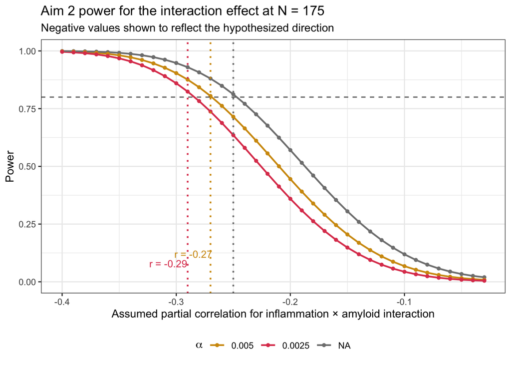

```r
aim2_plot_dat2 <- aim2_pwr_results %>%
  mutate(
    pc_plot = -pc,
    alpha = factor(
      alpha,
      levels = c(0.05, 0.01, 0.005, 0.0025),
      labels = c("0.05", "0.01",
        "0.005", "0.0025")))

aim2_min_pc_802 <- aim2_plot_dat2 %>%
  filter(power >= 0.80) %>%
  group_by(alpha) %>%
  slice_min(order_by = pc, n = 1, with_ties = FALSE) %>%
  ungroup() %>%
  mutate(
    pc_label = paste0("r = ", round(pc_plot, 2)),
    label_x = pc_plot - 0.015,
    label_y = 0.08)


aim2_min_pc_80_labels2 <- aim2_min_pc_802 %>%
  mutate(
    pc_label = paste0("r = ", round(-pc, 2)),
    label_x = case_when(
      alpha == "0.05"  ~ pc_plot + 0.017,
      alpha == "0.01"  ~ pc_plot + 0.017,
      alpha == "0.005"  ~ pc_plot - 0.015,
      alpha == "0.0025" ~ pc_plot - 0.017),
    label_y = case_when(
      alpha == "0.05"  ~ 0.08,
      alpha == "0.01"  ~ 0.08,
      alpha == "0.005"  ~ 0.12,
      alpha == "0.0025" ~ 0.08))

ggplot(aim2_plot_dat2, aes(x = pc_plot, y = power, color = alpha)) +
  geom_line(linewidth = 0.8) +
  geom_point(size = 1.2) +
  geom_hline(yintercept = 0.80, linetype = "dashed", color = "grey40") +
  geom_vline(
    data = aim2_min_pc_802,
    aes(xintercept = pc_plot, color = alpha),
    linetype = "dotted",
    linewidth = 0.8,
    show.legend = F) +
  geom_text(
    data = aim2_min_pc_80_labels2,
    aes(x = label_x, y = label_y, label = pc_label, color = alpha),
    size = 3.5,
    show.legend = F) +
  scale_color_manual(
    values = c("0.01" = "steelblue", "0.005" = "#d2980d",
       "0.0025" = "#de425b")) +
  labs(
    x = "Assumed partial correlation for inflammation × amyloid interaction",
    y = "Power",
    color = expression(alpha),
    title = "Aim 2 power for the interaction effect at N = 175",
    subtitle = "Negative values shown to reflect the hypothesized direction") +
  coord_cartesian(ylim = c(0, 1)) +
  theme_bw() +
  theme(legend.position = "bottom")
```

```r
sidak <- function(alpha, m) {
  1- (1-alpha)^(1/m)}
```

```r
sidak(alpha = 0.05, m = 20)
```

```
## [1] 0.002561379
```

```r
0.05/20
```

```
## [1] 0.0025
```

what analysis would we perform to test for confounders (mediator) vs precision variables sensitivity analysis for any potential confounders

```r
N_total <- 175
alpha <- 0.05/4  # assuming 4 independent tests

## low amyloid group: small plausible correlations
#rho_low_grid <- c(-0.10, -0.20, -0.30)
rho_low_grid <- c(0.10, 0.20, 0.30)

## plausible high-amyloid correlations
#rho_high_grid <- seq(-0.70, -0.10, by = 0.01)
rho_high_grid <- seq(0.20, 0.8, by = 0.01)

## ratio = n_high / n_low
nratio_grid <- c(1, 0.75, 0.5, 0.25)

aim2_corr2samp_results <- data.frame()

for (rho_low in rho_low_grid) {
  for (rho_high in rho_high_grid) {
    for (nr in nratio_grid) {

      ## ensure analysis only considers cases where
      ## |rho_high| > |rho_low|
      if (abs(rho_high) <= abs(rho_low)) next

      ## group sizes
      n_low  <- floor(N_total / (1 + nr))
      n_high <- N_total - n_low

      pwr_obj <- corr.2samp(
        n1      = n_low,
        n.ratio = n_high / n_low,
        rho1    = rho_low,
        rho2    = rho_high,
        alpha   = alpha,
        sides   = 2)

      power_val <- if (is.list(pwr_obj) && "power" %in% names(pwr_obj)) {
        pwr_obj$power
        } else {
          as.numeric(pwr_obj)
          }

      aim2_corr2samp_results <- rbind(
        aim2_corr2samp_results,
        data.frame(
          alpha    = alpha,
          rho_low  = rho_low,
          rho_high = rho_high,
          n_low    = n_low,
          n_high   = n_high,
          n_ratio  = n_high / n_low,
          power    = power_val))
    }
  }
  }
```

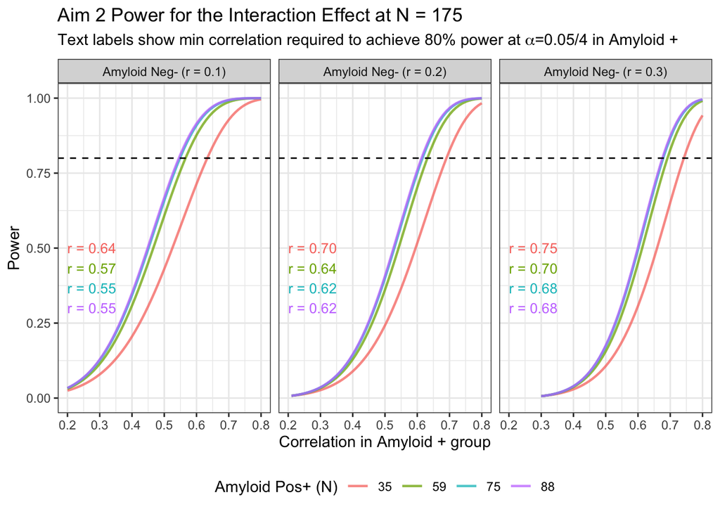

```r
# better labels for facet grid
# aim2_corr2samp_results$pos_label <- paste0(
# "Amyloid+ : ", aim2_corr2samp_results$n_high)

aim2_corr2samp_results$pos_label <- paste0(aim2_corr2samp_results$n_high)

aim2_corr2samp_results$neg_label <- paste0(
"Amyloid Neg- : ", aim2_corr2samp_results$n_low)

# create labels for rho for each facet grid
annot_df <- aim2_corr2samp_results %>%
  group_by(rho_low, pos_label) %>%
  filter(power >= 0.80) %>%
  slice_min(order_by = rho_high, n = 1, with_ties = FALSE) %>%
  ungroup() %>%
  mutate(label = paste0("r = ", sprintf("%.2f", rho_high)))

annot_df <- aim2_corr2samp_results %>%
  group_by(rho_low, pos_label, n_high) %>%
  summarise(
    rho_star = if (any(power >= 0.80))
      min(rho_high[power >= 0.80]) else NA_real_, # change to max if using neg
    .groups = "drop") %>%
  mutate(
    label = ifelse(
      is.na(rho_star),
      "min not reached",
      paste0("r = ", sprintf("%.2f", rho_star))),
    rho_low = factor(rho_low,levels = c(0.1, 0.2, 0.3))) %>%
  group_by(rho_low) %>%
  arrange(desc(n_high)) %>%
  mutate(
    x = 0.2,
    y = seq(0.30, 0.50, length.out = n())) %>%
  ungroup()

ggplot(aim2_corr2samp_results,
       aes(x = rho_high, y = power,
           color = pos_label,
           group = pos_label)) +
  geom_line(linewidth = 0.8, alpha = 0.75) +
  geom_hline(yintercept = 0.80, linetype = "dashed") +
  geom_text(data = annot_df,
    aes(x = x, y = y, label = label, color = pos_label),
    inherit.aes = FALSE, hjust = 0, size = 3.5, show.legend = FALSE) +
  facet_wrap(~ rho_low, nrow = 1,
    labeller = labeller(
      rho_low = function(x) paste0("Amyloid Neg- (r = ", x, ")"))) +
  scale_x_continuous("Correlation in Amyloid + group",
                     breaks = seq(0.2, 1, by = 0.1))  +
  scale_y_continuous("Power", limits = c(0, 1)) +
  scale_color_discrete(name = "Amyloid Pos+ (N)") +
    labs(
    title = "Aim 2 Power for the Interaction Effect at N = 175",
    subtitle = expression(paste("Text labels show min correlation required to achieve 80% power at ", alpha, "=0.05/4 in Amyloid +"))) +
  theme_bw() +
  theme(legend.position = "bottom")
```

```r
threshold_table <- aim2_corr2samp_results %>%
  arrange(alpha, n_ratio, abs(rho_high)) %>%
  group_by(alpha, n_ratio) %>%
  filter(power >= 0.80) %>%
  slice(1) %>%
  ungroup()

threshold_table
```

```
## # A tibble: 4 × 9
##    alpha rho_low rho_high n_low n_high n_ratio power pos_label neg_label
##    <dbl>   <dbl>    <dbl> <dbl>  <dbl>   <dbl> <dbl> <chr>     <chr>
## 1 0.0125     0.1     0.64   140     35   0.25  0.816 35        Amyloid Neg- : 1…
## 2 0.0125     0.1     0.57   116     59   0.509 0.810 59        Amyloid Neg- : 1…
## 3 0.0125     0.1     0.55   100     75   0.75  0.803 75        Amyloid Neg- : 1…
## 4 0.0125     0.1     0.55    87     88   1.01  0.812 88        Amyloid Neg- : 87
```

```r
# play around with different scenarios
corr.2samp(
  n1= 87,
  n.ratio = 88 / 87,
  rho1 = 0.075, # when neg amyloid group neg. corr incr -> pwr incr and vice-versa
  rho2 = 0.5, # weaker high amyloid corr lowers pwr
  alpha = 0.025,
  sides = 2)
```

```
## [1] 0.8041282
```

```r
corr.2samp(
  n1= 87,
  n.ratio = 88 / 87,
  rho1 = 0.2,
  rho2 = -0.4,
  alpha = 0.01,
  sides = 2)
```

```
## [1] 0.9355028
```

```r
corr.2samp(
  n1= 87,
  n.ratio = 88 / 87,
  rho1 = 0.3,
  rho2 = -0.4,
  alpha = 0.01,
  sides = 2)
```

```
## [1] 0.9866529
```

If the results aren’t as correlated as we expected, then we have to treat each test as independent

### Sesnitivity Analysis

Using a different package

```r
aim2_ipower <- InteractionPoweR::power_interaction(
  n.iter = 1000,
  N = 175, # target
  r.x1.y = 0.10, # r btw inflammation and outcome
  r.x2.y = 0.00, # r btw amyloid and outcome - **purely speculative**
  r.x1x2.y = seq(0.05, 0.30, by = 0.01), # r btw interaction and outcome
  r.x1.x2 = 0.05, # r btw amyloid and inflammation
  k.x1 = 0, # number of categories for x1
  k.x2 = 2, # number of categories for x2 (amyloid will be binary)
  k.y = 0, # number of categories for outcome (continuous outcome)
  alpha = c(0.01, 0.005, 0.0025),
  cl = parallel::detectCores() - 5,
  detailed_results = T) %>%
  rename(power = pwr)
```

```r
aim2_ipower_min <- aim2_ipower %>%
  filter(power >= 0.80) %>%
  group_by(alpha) %>%
  slice_min(r.x1x2.y, n = 1, with_ties = FALSE) %>%
  ungroup()

aim2_ipower_min_labels <- aim2_ipower_min %>%
  arrange(desc(alpha)) %>%
  mutate(
    label_x = max(aim2_ipower$r.x1x2.y) - 0.005,
    label_y = 0.05 + row_number() * 0.06,
    label = sprintf("r = %.2f", r.x1x2.y)) %>%
  ungroup()

ggplot(aim2_ipower,
       aes(x = r.x1x2.y, y = power, color = factor(alpha), group = alpha)) +
  geom_line(linewidth = 0.8) +
  geom_hline(yintercept = 0.80, linetype = "dashed", color = "grey40") +
  geom_vline(
    data = aim2_ipower_min,
    aes(xintercept = r.x1x2.y, color = factor(alpha)),
    linetype = "dotted",
    show.legend = FALSE) +
  geom_text(
    data = aim2_ipower_min_labels,
    aes(x = label_x, y = label_y, label = label, color = factor(alpha)),
    hjust = 1,
    size = 3.5,
    show.legend = FALSE) +
  facet_wrap(~ alpha, ncol = 2) +
  labs(
    x = "Assumed interaction effect correlation",
    y = "Power",
    color = expression(alpha),
    title = "Aim 2 interaction power by sample size") +
  theme_bw()+
  theme(legend.position = "bottom")
```

[output not shown]

Power analyses suggest that the proposed sample size is likely adequate for detecting moderate interaction effects in Aim 2, but may be underpowered for small interaction effects. Thus, the current design appears more suitable for detecting relatively strong inflammation × amyloid effects than subtle moderation effects.

### Summary of Analyses

| Aim | Hypothesis | Primary Outcome | Primary Exposure | Covariates |
| --- | --- | --- | --- | --- |
| 1 | H1a | 1-yr Δ in CVLT, Benson Figure, MST, and Store Recall (continuous cognitive measures); 1-yr Δ in AD-signature cortical thickness (continuous) | Baseline inflammatory markers (continuous cytokines: IL-6, TNF-α, continuous chemokines:MCP-1, Eotaxin-1) | Baseline age, sex, & baseline outcome |
| 1 | H1b | Same outcomes | Change in inflammatory markers (baseline → year-1) | Baseline age, sex, baseline outcome, and baseline inflammatory marker level |
| 2 | H2 | Same outcomes | baseline Inflammation × baseline amyloid interaction | Same as H1b |

Each hypothesis family will first be evaluated with a prespecified omnibus/global test at two-sided α = 0.05. If significant, follow-up pairwise models will be interpreted using Holm-adjusted inference within that family.

To address multiplicity prospectively, analyses will be organized into prespecified hypothesis families corresponding to H1a, H1b, and Aim 2. Within each family, the family-wise type I error rate will be controlled at two-sided α = 0.05 using the Holm sequential procedure. For sample size estimation, conservative power calculations will be based on the Bonferroni-equivalent threshold for the number of tests in each family, while final inference will use the prespecified Holm procedure, which provides greater power than simple Bonferroni adjustment.

To address multiplicity prospectively, analyses will be organized into prespecified hypothesis families corresponding to H1a, H1b, and Aim 2. Within each family, the family-wise type I error rate will be controlled at two-sided α = 0.05 using the Holm’s step-down procedure. For power estimation, we will evaluate a range of significance thresholds to reflect uncertainty in the effective number of correlated tests within each family. Specifically, power will be examined under the conservative Bonferroni threshold based on the full number of planned tests in the family (5 outcomes x 4 markers = 20), as well as under less conservative thresholds reflecting plausible reductions in the effective number of tests due to correlation among inflammatory markers and outcomes. This range will include the most conservative threshold and selected intermediate values to provide lower- and upper-bound estimates of detectable effect sizes.

Because preliminary analyses indicate non-independence among several predictors and outcomes, the nominal number of model tests likely overstates the number of statistically independent pieces of information. Therefore, a Bonferroni correction based on the full cross-product of predictors and outcomes would likely be overly conservative

the true effective multiplicity burden is likely between the extreme cases of complete independence and complete redundancy.